# Latihan Pertemuan 7 Analisis Regresi

### Normalitas Sisaan dengan QQ-Plot

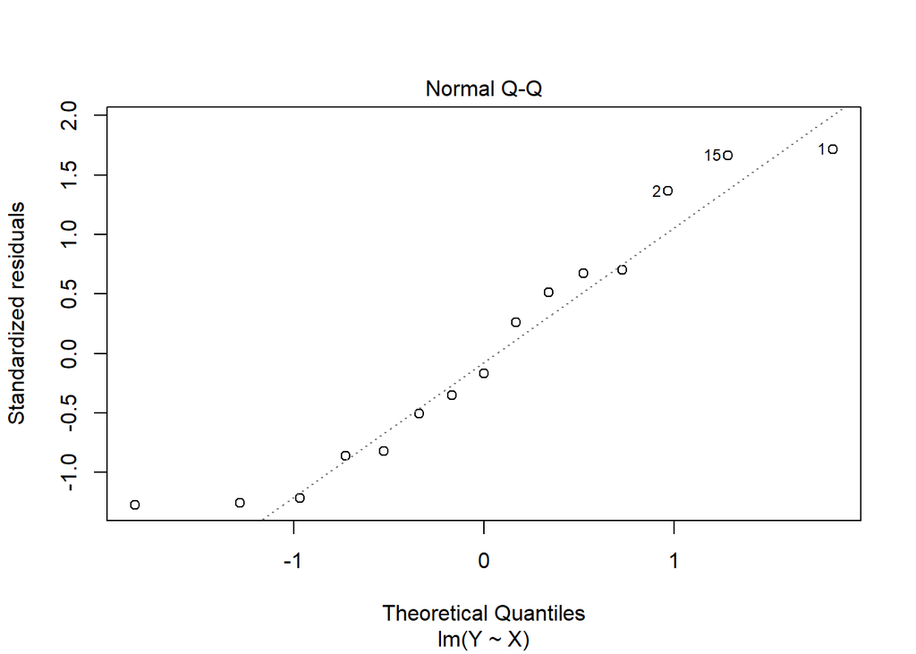

```r
plot(model,2)
```

## Uji Formal Asumsi

### Kondisi Gauss Marcov

#### 1. Nilai Harapan Sisaan sama dengan Nol

$$H_0: \text{Nilai harapan sisaan sama dengan nol}\\
H_1: \text{Nilai harapan sisaan tidak sama dengan nol }\$$

```r
t.test(model$residuals,mu = 0,conf.level = 0.95)
```

```
##
##  One Sample t-test
##
## data:  model$residuals
## t = -4.9493e-16, df = 14, p-value = 1
## alternative hypothesis: true mean is not equal to 0
## 95 percent confidence interval:
##  -3.143811  3.143811
## sample estimates:
##     mean of x
## -7.254614e-16
```

P-value = 1 > alpha = 0.05, maka tak tolak H0 yang berarti nilai harapan sisaan sama dengan nol

#### 2. Ragam Sisaan Homogen

Uji formal untuk mendeteksi homogenitas ragam sisaan dapat dilakukan dengan uji Breusch-Pagan menggunakan fungsi bptest. Uji ini memiliki hipotesis sebagai berikut
$$H_0: var [ϵ] = σ^2I \text {(ragam sisaan homogen)} \\
H_1: var[ϵ] ≠ σ^2I \text {(ragam tidak homogen)}\$$

```r
kehomogenan = lm(formula = abs(model$residuals) ~ X, # y: abs residual
    data = datalatihan)
summary(kehomogenan)
```

```
##
## Call:
## lm(formula = abs(model$residuals) ~ X, data = datalatihan)
##
## Residuals:
##     Min      1Q  Median      3Q     Max
## -4.2525 -1.7525  0.0235  2.0168  4.2681
##
## Coefficients:
##             Estimate Std. Error t value Pr(>|t|)
## (Intercept)  5.45041    1.27241   4.284  0.00089 ***
## X           -0.01948    0.03456  -0.564  0.58266
## ---
## Signif. codes:  0 '***' 0.001 '**' 0.01 '*' 0.05 '.' 0.1 ' ' 1
##
## Residual standard error: 2.714 on 13 degrees of freedom
## Multiple R-squared:  0.02385,    Adjusted R-squared:  -0.05124
## F-statistic: 0.3176 on 1 and 13 DF,  p-value: 0.5827
```

```r
bptest(model)
```

```
##
##  studentized Breusch-Pagan test
##
## data:  model
## BP = 0.52819, df = 1, p-value = 0.4674
```

```r
ncvTest(model)
```

```
## Non-constant Variance Score Test
## Variance formula: ~ fitted.values
## Chisquare = 0.1962841, Df = 1, p = 0.65774
```

P-value = 0.4674 > alpha = 0.05, maka tak tolak H0 yang berarti ragam sisaan homogen

#### 3. Sisaan Saling Bebas

$$H_0: \text {Sisaan saling bebas} \\
H_1: \text {Sisaan tidak saling bebas}\$$

```r
dwtest(model)
```

```
##
##  Durbin-Watson test
##
## data:  model
## DW = 0.48462, p-value = 1.333e-05
## alternative hypothesis: true autocorrelation is greater than 0
```

Karena p-value = 1.333e-05 < alpha = 0.05, maka tolak H0 yang berarti sisaan tidak saling bebas, asumsi tidak terpenuhi

## Uji Formal Normalitas Sisaan

H0: Sisaan menyebar normal  
H1: Sisaan tidak menyebar normal

```r
shapiro.test(model$residuals)
```

```
##
##  Shapiro-Wilk normality test
##
## data:  model$residuals
## W = 0.92457, p-value = 0.226
```

Karena p-value = 0.226 > alpha = 0.05, maka tak tolak H0, sisaan menyebar normal

## Transformasi Data

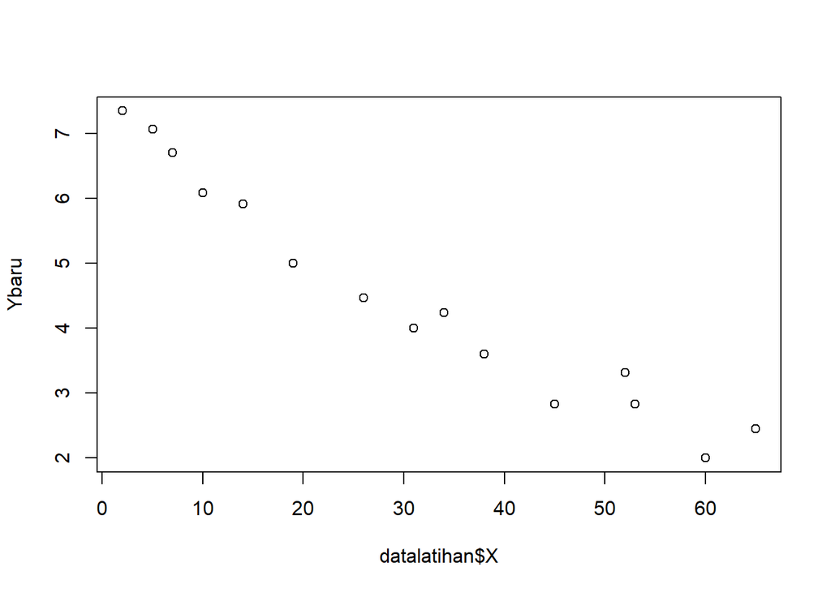

```r
Ybaru = sqrt(datalatihan$Y)
Xbaru = sqrt(datalatihan$X)

plot(x = datalatihan$X,y = Ybaru)
```

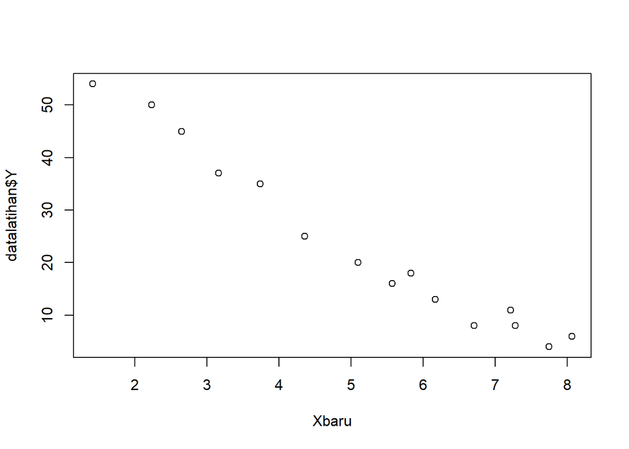

```r
plot(x = Xbaru, y = datalatihan$Y)
```

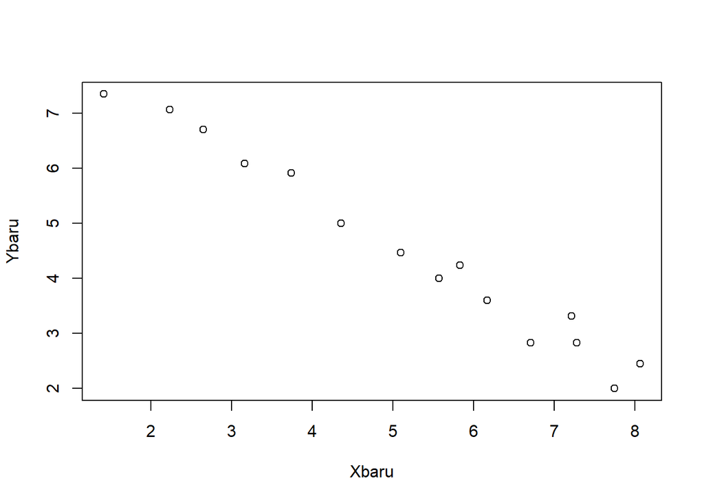

```r
plot(x = Xbaru, y = Ybaru)
```

```r
model2 = lm(formula = Ybaru ~ Xbaru)
summary(model2)
```

```
##
## Call:
## lm(formula = Ybaru ~ Xbaru)
##
## Residuals:
##      Min       1Q   Median       3Q      Max
## -0.42765 -0.17534 -0.05753  0.21223  0.46960
##
## Coefficients:
##             Estimate Std. Error t value Pr(>|t|)
## (Intercept)  8.71245    0.19101   45.61 9.83e-16 ***
## Xbaru       -0.81339    0.03445  -23.61 4.64e-12 ***
## ---
## Signif. codes:  0 '***' 0.001 '**' 0.01 '*' 0.05 '.' 0.1 ' ' 1
##
## Residual standard error: 0.2743 on 13 degrees of freedom
## Multiple R-squared:  0.9772, Adjusted R-squared:  0.9755
## F-statistic: 557.3 on 1 and 13 DF,  p-value: 4.643e-12
```

```r
dwtest(model2)
```

```
##
##  Durbin-Watson test
##
## data:  model2
## DW = 2.6803, p-value = 0.8629
## alternative hypothesis: true autocorrelation is greater than 0
```

Karena p-value = 0.8629 > alpha = 0.05, maka tak tolak H0yang berarti sisaan saling bebas dan asumsi terpenuhi

## Kesimpulan dan Transformasi Balik

Berdasarkan transformasi yang dilakukan yaitu transformasi $Y^{\frac12}\text{dan}X^{\frac12}$ akan menghasilkan model regresi yang lebih efektif disertai dengan semua asumsi telah terpenuhi dalam analisis regresi linear sederhana.

Model regresi setelah di transformasi adalah sebagai berikut :

$$Y^*=8.71245-0.81339X^* + ε$$

$$Y^* = \sqrt Y$$
$$X^* = \sqrt X$$